# Lab Assignment Six: Convolutional Network Architectures

# Team Member Information:

```python
import pandas as pd
names = ['Jiaqi Song','Yuchao Zhang','Zhenxuan Ouyang','Jianmin Li']
smuid = [47534426, 47787029, 47784546, 47794972]
teaminfo = pd.DataFrame()
teaminfo['name'] = names
teaminfo['smu id'] = smuid
teaminfo
```

|  | name | smu id |
| --- | --- | --- |
| 0 | Jiaqi Song | 47534426 |
| 1 | Yuchao Zhang | 47787029 |
| 2 | Zhenxuan Ouyang | 47784546 |
| 3 | Jianmin Li | 47794972 |

# 1. Preparation (30 points total)

## 1.1 Evaluation Metrics

The Facial Expression Recognition dataset contains 35887 images, which has 1 numeric feature for image pixels and 1 categorical feature for facial expressions. Each image consists of a 48x48 pixel grayscale face that has been automatically registered to be centered and occupy about the same amount of space. Along with each image, there is a categorical number that represents the feeling of people inside the image (0=Angry, 1=Disgust, 2=Fear, 3=Happy, 4=Sad, 5=Surprise, 6=Neutral), which is also the prediction task for this lab.  
Nowadays, there are many advertisements in the public, such as squares, bus stations, shopping malls, etc. Suppose there is a company who put up advertisements for their new product in various public places, and they want to know what are the citizens' reactions to these advertisements. So, they can adjust the content of their advertisement dynamically and increase the sales hopefully. They can install microcameras besides their advertisements board, and capture the facial emotions of the citizens after they watch the advertisements. The goal of our model is to distinguish different emotions precisely, then the company can know whether they should change the advertisement or not. If the proportion of bad emotions, such as angry, disgust, fear, exceeds a certain limit set up earlier, then the company need to adjust the content of that advertisement.

```python
# load data
import pandas as pd
import numpy as np
import sklearn
import matplotlib.pyplot as plt
import warnings
warnings.filterwarnings('ignore')

df = pd.read_csv("fer2013.csv")
```

```python
display(df.shape)
df.head(5)
```

```
(35887, 3)
```

|  | emotion | pixels | Usage |
| --- | --- | --- | --- |
| 0 | 0 | 70 80 82 72 58 58 60 63 54 58 60 48 89 115 121... | Training |
| 1 | 0 | 151 150 147 155 148 133 111 140 170 174 182 15... | Training |
| 2 | 2 | 231 212 156 164 174 138 161 173 182 200 106 38... | Training |
| 3 | 4 | 24 32 36 30 32 23 19 20 30 41 21 22 32 34 21 1... | Training |
| 4 | 6 | 4 0 0 0 0 0 0 0 0 0 0 0 3 15 23 28 48 50 58 84... | Training |

```
[4953  547 5121 8989 6077 4002 6198]
```

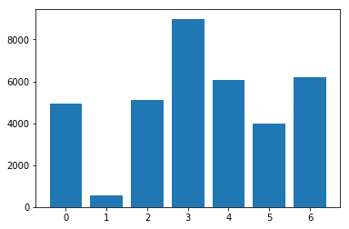

```python
vals = np.bincount(df.emotion)
print(vals)
plt.bar(range(len(vals)),vals)
plt.show()
```

In this lab, we choose F1 score as our metric. First of all, from the above distribution of each class, we know that the dataset is not evenly distributed. So, accuracy score is not appropriate to our model. Our goal is to distinguish different facial expressions precisely for the company, then the company will make decisions on whether or not to adjust their advertisement based on our results. If we predict lots of good emotions to bad emotions, which will most likely make the company to change their advertisements. While, actually they do not need to change, so this will generate lots of unnecessary expense. And the new advertisement may turn out to be bad, this will cost more to change it again, and eventually this may decrease the sales. On the other hand, if we predict many bad emotions to good emotions, the company would think the advertisement is good and no change needed. Actually, the advertisement is bad, and this will mostly likely lead to a bad sales. In general, we want to make sure that both the false positive and false negative to be small, so we use F1 score.

## 1.2 Splitting the Data

For this dataset, we are going to use Stratified 10-fold cross validation. First we split original data into 80% training data and 20% unseen test data. Then we break the training data up into 10 partitions and then, 10 times in turn, we select one partition for testing and use the remaining ones for training.  
From the group by results above, although we have more than 30000 images which is abundant enough to train our models, the number of each class isn't entirely balanced. We can see that the class '1' which represent 'Disgust' has only 547 instances and it is much less than the number of instances of ohter classes. If we simply shufflesplit the dataset, a circumstance may occur that there isn't any 'Disgust' instance in one of the folds, which will weaken the ability of the model to classify this class. Besides, the dataset is neither time-series nor any sort of ordered series. Therefore, Stratified 10-fold is a suitable way of cross validation for our dataset. After we finish training our models, we then evaluate the general performance by using 20% unseen test data.

# 2. Modeling (60 points total)

```python
df = df.reset_index(drop=True)
df.shape
```

```
(35887, 3)
```

```python
%%time
df1 = df.copy()
for i in range(len(df1.pixels)):
    df1.pixels[i] = np.array(list(map(int,df1.pixels[i].split(' '))))

X = np.array([i for i in df1.pixels])
y = np.array([i for i in df1.emotion])
n_samples, n_features = X.shape
names = np.array([i for i in df1.emotion])
# the shape of each picture
h = 48
w = 48
n_pictures = len(df1.pixels)
n_pixels = len(df1.pixels[0])
```

```
CPU times: user 10min 33s, sys: 1.89 s, total: 10min 35s
Wall time: 10min 35s
```

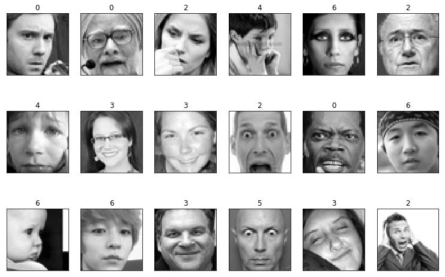

```python
# a helper plotting function
# 0=Angry, 1=Disgust, 2=Fear, 3=Happy, 4=Sad, 5=Surprise, 6=Neutral
def plot_gallery(images, titles, h, w, n_row=3, n_col=6):
    """Helper function to plot a gallery of portraits"""
    plt.figure(figsize=(1.7 * n_col, 2.3 * n_row))
    plt.subplots_adjust(bottom=0, left=.01, right=.99, top=.90, hspace=.35)
    for i in range(n_row * n_col):
        plt.subplot(n_row, n_col, i + 1)
        plt.imshow(images[i].reshape((h, w)), cmap=plt.cm.gray)
        plt.title(titles[i], size=12)
        plt.xticks(())
        plt.yticks(())

plot_gallery(df1.pixels, df1.emotion, h, w, 3, 6)
```

```python
import keras
from keras.models import Sequential
from keras.layers import Reshape
from keras.layers import Dense, Dropout, Activation, Flatten
from keras.layers import Conv2D, MaxPooling2D
from keras.preprocessing.image import ImageDataGenerator
from keras.callbacks import EarlyStopping
from keras.regularizers import l2
from keras.layers import average
from keras.models import Input, Model

keras.__version__
```

```
'2.2.2'
```

```python
# 0=Angry, 1=Disgust, 2=Fear, 3=Happy, 4=Sad, 5=Surprise, 6=Neutral
classes = ['Angry', 'Disgust', 'Fear',
          'Happy', 'Sad','Surprise','Neutral']
img_wh = 48
NUM_CLASSES = len(classes)
```

```python
from sklearn.model_selection import train_test_split

X_train, X_test, y_train, y_test = train_test_split(X, y, test_size=0.2, stratify=y)

X_train = X_train/255.0 - 0.5
X_test = X_test/255.0 - 0.5

# NEW: Let's start by fixing the sizes
X_train = np.expand_dims(X_train.reshape((-1,img_wh,img_wh)), axis=3)
X_test = np.expand_dims(X_test.reshape((-1,img_wh,img_wh)), axis=3)
# the image data has been resized to (samples,image_rows,image_cols,image_channels)

# and one hot encoding the output values
y_train_ohe = keras.utils.to_categorical(y_train, NUM_CLASSES)
y_test_ohe = keras.utils.to_categorical(y_test, NUM_CLASSES)

print(X_train.shape)
print(X_test.shape)
```

```
(28709, 48, 48, 1)
(7178, 48, 48, 1)
```

First, we load the dataset and convert pixel into numpy array, then we preprocess our dataset by splitting dataset into 80% training data and 20% testing data, expanding dimension of data and one hot encoding output values. As we can see above, we have 7 classes, our image is 48 * 48 pixel.

## 2.1 CNN and Data Expansion

#### [15 points] Create a convolutional neural network to use on your data using Keras. Setup the training to use data expansion in Keras. Explain why the chosen data expansion techniques are appropriate for your dataset.

```python
# Since Keras removed f1_score at version 2.0.0, we use the calculation function from others
# Source: https://github.com/keras-team/keras/issues/5400, by Unnir

from keras import backend as K

def mcor(y_true, y_pred):
     #matthews_correlation
    y_pred_pos = K.round(K.clip(y_pred, 0, 1))
    y_pred_neg = 1 - y_pred_pos

    y_pos = K.round(K.clip(y_true, 0, 1))
    y_neg = 1 - y_pos

    tp = K.sum(y_pos * y_pred_pos)
    tn = K.sum(y_neg * y_pred_neg)

    fp = K.sum(y_neg * y_pred_pos)
    fn = K.sum(y_pos * y_pred_neg)

    numerator = (tp * tn - fp * fn)
    denominator = K.sqrt((tp + fp) * (tp + fn) * (tn + fp) * (tn + fn))

    return numerator / (denominator + K.epsilon())

def precision(y_true, y_pred):
    """Precision metric.

    Only computes a batch-wise average of precision.

    Computes the precision, a metric for multi-label classification of
    how many selected items are relevant.
    """
    true_positives = K.sum(K.round(K.clip(y_true * y_pred, 0, 1)))
    predicted_positives = K.sum(K.round(K.clip(y_pred, 0, 1)))
    precision = true_positives / (predicted_positives + K.epsilon())
    return precision

def recall(y_true, y_pred):
    """Recall metric.

    Only computes a batch-wise average of recall.

    Computes the recall, a metric for multi-label classification of
    how many relevant items are selected.
    """
    true_positives = K.sum(K.round(K.clip(y_true * y_pred, 0, 1)))
    possible_positives = K.sum(K.round(K.clip(y_true, 0, 1)))
    recall = true_positives / (possible_positives + K.epsilon())
    return recall

def f1(y_true, y_pred):
    def recall(y_true, y_pred):
        """Recall metric.

        Only computes a batch-wise average of recall.

        Computes the recall, a metric for multi-label classification of
        how many relevant items are selected.
        """
        true_positives = K.sum(K.round(K.clip(y_true * y_pred, 0, 1)))
        possible_positives = K.sum(K.round(K.clip(y_true, 0, 1)))
        recall = true_positives / (possible_positives + K.epsilon())
        return recall

    def precision(y_true, y_pred):
        """Precision metric.

        Only computes a batch-wise average of precision.

        Computes the precision, a metric for multi-label classification of
        how many selected items are relevant.
        """
        true_positives = K.sum(K.round(K.clip(y_true * y_pred, 0, 1)))
        predicted_positives = K.sum(K.round(K.clip(y_pred, 0, 1)))
        precision = true_positives / (predicted_positives + K.epsilon())
        return precision
    precision = precision(y_true, y_pred)
    recall = recall(y_true, y_pred)
    return 2*((precision*recall)/(precision+recall+K.epsilon()))
```

Since we used F1 score evaluation metrics, we need to implement f1 score metrics by ourself because Keras removed f1_score at version 2.0.0. Here we use the calculation function from other programmers. Source: https://github.com/keras-team/keras/issues/5400, by Unnir

```python
datagen = ImageDataGenerator(featurewise_center=False,
    samplewise_center=False,
    featurewise_std_normalization=False,
    samplewise_std_normalization=False,
    zca_whitening=False,
    rotation_range=5, # used, Int. Degree range for random rotations.
    width_shift_range=0.1, # used, Float (fraction of total width). Range for random horizontal shifts.
    height_shift_range=0.1, # used,  Float (fraction of total height). Range for random vertical shifts.
    shear_range=0., # Float. Shear Intensity (Shear angle in counter-clockwise direction as radians)
    zoom_range=0.,
    channel_shift_range=0.,
    fill_mode='nearest',
    cval=0.,
    horizontal_flip=True,
    vertical_flip=False,
    rescale=None)

datagen.fit(X_train)
```

We are using Face Expression Recognization dataset for this lab. Even for the same emotion of the same person like 'happy', he may perform different facial expressions according to how happy he is, that is, which level of happy he is in at that time. Besides, the face with expressions are more likely to be asymmetric and the head may be in a angle rather that vertical to the ground. Therefore, we use a data generator to generate faces that have slight rotation or symmetric of the original data.

## Alex Net

```python
alex_net = Sequential()

# let's start with an AlexNet style convolutional phase
alex_net.add(Conv2D(filters=64,
                input_shape = (img_wh,img_wh,1),
                kernel_size=(5,5),
                padding='same',
                activation='relu', data_format="channels_last")) # more compact syntax

# no max pool before next conv layer!!
alex_net.add(Conv2D(filters=128,
                kernel_size=(5,5),
                padding='same',
                activation='relu')) # more compact syntax
alex_net.add(MaxPooling2D(pool_size=(2, 2), data_format="channels_last"))


# add one layer on flattened output
alex_net.add(Dropout(0.25)) # add some dropout for regularization after conv layers
alex_net.add(Flatten())
alex_net.add(Dense(128, activation='relu'))
alex_net.add(Dropout(0.5)) # add some dropout for regularization, again!
alex_net.add(Dense(NUM_CLASSES, activation='softmax'))
alex_net.summary()
```

```
_________________________________________________________________
Layer (type)                 Output Shape              Param #
=================================================================
conv2d_30 (Conv2D)           (None, 48, 48, 64)        1664
_________________________________________________________________
conv2d_31 (Conv2D)           (None, 48, 48, 128)       204928
_________________________________________________________________
max_pooling2d_23 (MaxPooling (None, 24, 24, 128)       0
_________________________________________________________________
dropout_21 (Dropout)         (None, 24, 24, 128)       0
_________________________________________________________________
flatten_13 (Flatten)         (None, 73728)             0
_________________________________________________________________
dense_41 (Dense)             (None, 128)               9437312
_________________________________________________________________
dropout_22 (Dropout)         (None, 128)               0
_________________________________________________________________
dense_42 (Dense)             (None, 7)                 903
=================================================================
Total params: 9,644,807
Trainable params: 9,644,807
Non-trainable params: 0
_________________________________________________________________
```

```python
# Let's train the model
alex_net.compile(loss='categorical_crossentropy', # 'categorical_crossentropy' 'mean_squared_error'
              optimizer='rmsprop', # 'adadelta' 'rmsprop'
              metrics=[f1])
```

```python
# the flow method yields batches of images indefinitely, with the given transformations
alex_net.fit_generator(datagen.flow(X_train, y_train_ohe, batch_size=128),
                   steps_per_epoch=int(len(X_train)/128), # how many generators to go through per epoch
                   epochs=30, verbose=1,
                   validation_data=(X_test,y_test_ohe)
                  )
```

```
<keras.callbacks.History at 0x2aab767c2b70>
```

## 2.2 Model Evaluation

#### [20 points] Investigate at least two different convolutional network architectures (and investigate changing some parameters of each architecture). Use the method of cross validation and evaluation metric that you argued for at the beginning of the lab. Visualize the performance of the training and validation sets per iteration (use the "history" parameter of Keras).

### Resnet

```python
%%time

# now lets use the LeNet architecture with batch norm
# We will also use ReLU where approriate and drop out
from keras.layers.normalization import BatchNormalization
from keras.layers import Add
from keras.layers import average, concatenate
from keras.models import Input, Model
from keras.regularizers import l2
l2_lambda = 0.00001

input_holder = Input(shape=(img_wh, img_wh, 1))

# start with a conv layer
x = Conv2D(filters=64, # change the number of filters
               input_shape = (img_wh,img_wh,1),
               kernel_size=(3,3),
               kernel_initializer='he_uniform',
               kernel_regularizer=l2(l2_lambda),
               padding='same',
               activation='relu',
               data_format="channels_last")(input_holder)

x = MaxPooling2D(pool_size=(2, 2), data_format="channels_last")(x)

x = Conv2D(filters=32,
               kernel_size=(3,3),
               kernel_initializer='he_uniform',
               kernel_regularizer=l2(l2_lambda),
               padding='same',
               activation='relu',
               data_format="channels_last")(x)

x_split = MaxPooling2D(pool_size=(2, 2), data_format="channels_last")(x)

x = Conv2D(filters=64,
               kernel_size=(1,1),
               kernel_initializer='he_uniform',
               kernel_regularizer=l2(l2_lambda),
               padding='same',
               activation='relu',
               data_format="channels_last")(x_split)

x = Conv2D(filters=64,
               kernel_size=(3,3),
               kernel_initializer='he_uniform',
               kernel_regularizer=l2(l2_lambda),
               padding='same',
               activation='relu',
               data_format="channels_last")(x)

x = Conv2D(filters=32,
               kernel_size=(1,1),
               kernel_initializer='he_uniform',
               kernel_regularizer=l2(l2_lambda),
               padding='same',
               activation='relu',
               data_format="channels_last")(x)

# now add back in the split layer, x_split (residual added in)
x = Add()([x, x_split])
x = Activation("relu")(x)

x = MaxPooling2D(pool_size=(2, 2), data_format="channels_last")(x)

x = Flatten()(x)
x = Dropout(0.25)(x)
x = Dense(256)(x)
x = Activation("relu")(x)
x = Dropout(0.5)(x)
x = Dense(NUM_CLASSES)(x)
x = Activation('softmax')(x)

resnet = Model(inputs=input_holder,outputs=x)

resnet.summary()
```

```
__________________________________________________________________________________________________
Layer (type)                    Output Shape         Param #     Connected to
==================================================================================================
input_12 (InputLayer)           (None, 48, 48, 1)    0
__________________________________________________________________________________________________
conv2d_32 (Conv2D)              (None, 48, 48, 64)   640         input_12[0][0]
__________________________________________________________________________________________________
max_pooling2d_24 (MaxPooling2D) (None, 24, 24, 64)   0           conv2d_32[0][0]
__________________________________________________________________________________________________
conv2d_33 (Conv2D)              (None, 24, 24, 32)   18464       max_pooling2d_24[0][0]
__________________________________________________________________________________________________
max_pooling2d_25 (MaxPooling2D) (None, 12, 12, 32)   0           conv2d_33[0][0]
__________________________________________________________________________________________________
conv2d_34 (Conv2D)              (None, 12, 12, 64)   2112        max_pooling2d_25[0][0]
__________________________________________________________________________________________________
conv2d_35 (Conv2D)              (None, 12, 12, 64)   36928       conv2d_34[0][0]
__________________________________________________________________________________________________
conv2d_36 (Conv2D)              (None, 12, 12, 32)   2080        conv2d_35[0][0]
__________________________________________________________________________________________________
add_10 (Add)                    (None, 12, 12, 32)   0           conv2d_36[0][0]
                                                                 max_pooling2d_25[0][0]
__________________________________________________________________________________________________
activation_13 (Activation)      (None, 12, 12, 32)   0           add_10[0][0]
__________________________________________________________________________________________________
max_pooling2d_26 (MaxPooling2D) (None, 6, 6, 32)     0           activation_13[0][0]
__________________________________________________________________________________________________
flatten_14 (Flatten)            (None, 1152)         0           max_pooling2d_26[0][0]
__________________________________________________________________________________________________
dropout_23 (Dropout)            (None, 1152)         0           flatten_14[0][0]
__________________________________________________________________________________________________
dense_43 (Dense)                (None, 256)          295168      dropout_23[0][0]
__________________________________________________________________________________________________
activation_14 (Activation)      (None, 256)          0           dense_43[0][0]
__________________________________________________________________________________________________
dropout_24 (Dropout)            (None, 256)          0           activation_14[0][0]
__________________________________________________________________________________________________
dense_44 (Dense)                (None, 7)            1799        dropout_24[0][0]
__________________________________________________________________________________________________
activation_15 (Activation)      (None, 7)            0           dense_44[0][0]
==================================================================================================
Total params: 357,191
Trainable params: 357,191
Non-trainable params: 0
__________________________________________________________________________________________________
CPU times: user 188 ms, sys: 6.88 ms, total: 195 ms
Wall time: 193 ms
```

```python
resnet.compile(loss='categorical_crossentropy', # 'categorical_crossentropy' 'mean_squared_error'
                optimizer='adam', # 'adadelta' 'rmsprop'
                metrics=[f1])
```

### Xception

```python
# Xception style architecture
from keras.layers import SeparableConv2D
from keras.layers.normalization import BatchNormalization
from keras.layers import Add
from keras.layers import average, concatenate
from keras.models import Input, Model

l2_lambda = 0.000001



input_holder = Input(shape=(img_wh, img_wh, 1))

# start with a conv layer
x = Conv2D(filters=64, # change the number of filters
               input_shape = (img_wh,img_wh,1),
               kernel_size=(3,3),
               kernel_initializer='he_uniform',
               kernel_regularizer=l2(l2_lambda),
               padding='same',
               activation='relu',
               data_format="channels_last")(input_holder)

x = MaxPooling2D(pool_size=(2, 2), data_format="channels_last")(x)

x = Conv2D(filters=32,
               kernel_size=(3,3),
               kernel_initializer='he_uniform',
               kernel_regularizer=l2(l2_lambda),
               padding='same',
               activation='relu',
               data_format="channels_last")(x)


x_split = MaxPooling2D(pool_size=(2, 2), data_format="channels_last")(x)

x = SeparableConv2D(filters=32,
               input_shape = (img_wh,img_wh,1),
               kernel_size=(3,3),
               kernel_initializer='he_uniform',
               kernel_regularizer=l2(l2_lambda),
               padding='same',
               activation='relu',
               depth_multiplier = 1, # controls output channels
               data_format="channels_last")(x_split)


x_split = Add()([x, x_split])

x = SeparableConv2D(filters=32,
               input_shape = (img_wh,img_wh,1),
               kernel_size=(3,3),
               kernel_initializer='he_uniform',
               kernel_regularizer=l2(l2_lambda),
               padding='same',
               activation='relu',
               depth_multiplier = 1, # controls output channels
               data_format="channels_last")(x_split)


x_split = Add()([x, x_split])


x = Activation("relu")(x_split)

x = MaxPooling2D(pool_size=(2, 2), data_format="channels_last")(x)

x = Flatten()(x)
x = Dropout(0.25)(x)
x = Dense(256, activation="relu")(x)
x = Dropout(0.5)(x)
x = Dense(NUM_CLASSES,activation="softmax")(x)

xception_model = Model(inputs=input_holder,outputs=x)

xception_model.summary()
```

```
__________________________________________________________________________________________________
Layer (type)                    Output Shape         Param #     Connected to
==================================================================================================
input_13 (InputLayer)           (None, 48, 48, 1)    0
__________________________________________________________________________________________________
conv2d_37 (Conv2D)              (None, 48, 48, 64)   640         input_13[0][0]
__________________________________________________________________________________________________
max_pooling2d_27 (MaxPooling2D) (None, 24, 24, 64)   0           conv2d_37[0][0]
__________________________________________________________________________________________________
conv2d_38 (Conv2D)              (None, 24, 24, 32)   18464       max_pooling2d_27[0][0]
__________________________________________________________________________________________________
max_pooling2d_28 (MaxPooling2D) (None, 12, 12, 32)   0           conv2d_38[0][0]
__________________________________________________________________________________________________
separable_conv2d_7 (SeparableCo (None, 12, 12, 32)   1344        max_pooling2d_28[0][0]
__________________________________________________________________________________________________
add_11 (Add)                    (None, 12, 12, 32)   0           separable_conv2d_7[0][0]
                                                                 max_pooling2d_28[0][0]
__________________________________________________________________________________________________
separable_conv2d_8 (SeparableCo (None, 12, 12, 32)   1344        add_11[0][0]
__________________________________________________________________________________________________
add_12 (Add)                    (None, 12, 12, 32)   0           separable_conv2d_8[0][0]
                                                                 add_11[0][0]
__________________________________________________________________________________________________
activation_16 (Activation)      (None, 12, 12, 32)   0           add_12[0][0]
__________________________________________________________________________________________________
max_pooling2d_29 (MaxPooling2D) (None, 6, 6, 32)     0           activation_16[0][0]
__________________________________________________________________________________________________
flatten_15 (Flatten)            (None, 1152)         0           max_pooling2d_29[0][0]
__________________________________________________________________________________________________
dropout_25 (Dropout)            (None, 1152)         0           flatten_15[0][0]
__________________________________________________________________________________________________
dense_45 (Dense)                (None, 256)          295168      dropout_25[0][0]
__________________________________________________________________________________________________
dropout_26 (Dropout)            (None, 256)          0           dense_45[0][0]
__________________________________________________________________________________________________
dense_46 (Dense)                (None, 7)            1799        dropout_26[0][0]
==================================================================================================
Total params: 318,759
Trainable params: 318,759
Non-trainable params: 0
__________________________________________________________________________________________________
```

```python
# speed up by training by not using augmentation, perhaps there are faster ways??
xception_model.compile(loss='categorical_crossentropy', # 'categorical_crossentropy' 'mean_squared_error'
                optimizer='adam', # 'adadelta' 'rmsprop'
                metrics=[f1])
```

Besides Alex net, we also set up resnet and xception net. Let's see how those three models perform!

```python
from sklearn.model_selection import StratifiedKFold
from sklearn.metrics import f1_score
```

### 2.2.1 Xception performance

```python
from matplotlib import pyplot as plt

n_folds = 10
skf = StratifiedKFold(n_splits=n_folds)

cv_training_f1_score = []
cv_training_loss = []

cv_val_f1_score = []
cv_val_loss = []


iternum = 1
for train_indices, val_indices in skf.split(X_train, y_train):
    X_tmp_train = X_train[train_indices]
    y_tmp_train = y_train_ohe[train_indices]

    X_tmp_val = X_train[val_indices]
    y_tmp_val = y_train_ohe[val_indices]

    history = xception_model.fit_generator(datagen.flow(X_tmp_train, y_tmp_train, batch_size=128),
                   steps_per_epoch=int(len(X_tmp_train)/128), # how many generators to go through per epoch
                   epochs=30, verbose=0,
                   validation_data=(X_tmp_val,y_tmp_val)
                  )
    # save the performance data of different training and validation set

    cv_training_f1_score.append(history.history.get('f1'))
    cv_val_f1_score.append(history.history.get('val_f1'))

    cv_training_loss.append(history.history.get('loss'))
    cv_val_loss.append(history.history.get('val_loss'))
```

### (Xception) Visualize the training and validation f1_score and loss of each iteration of every fold

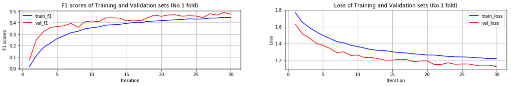

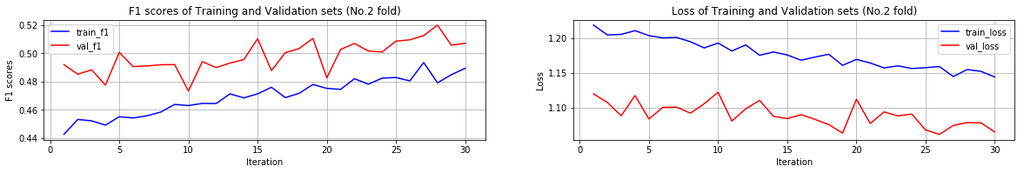

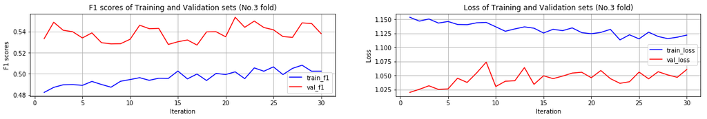

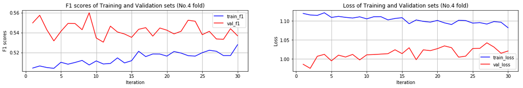

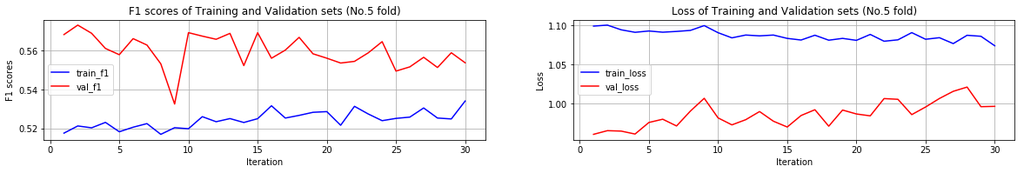

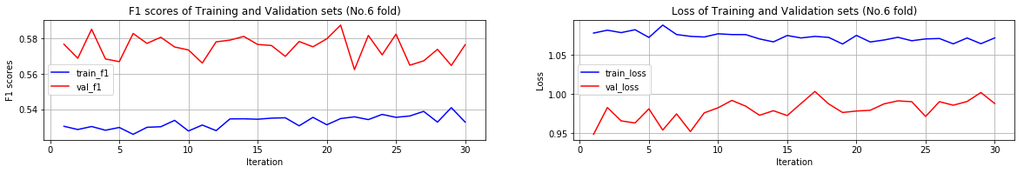

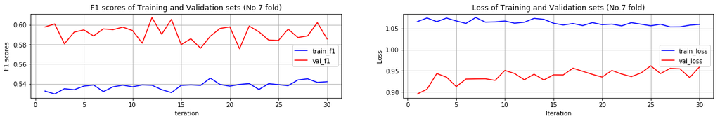

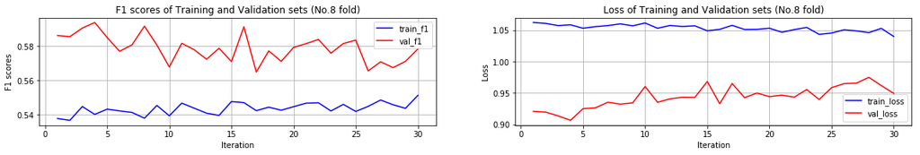

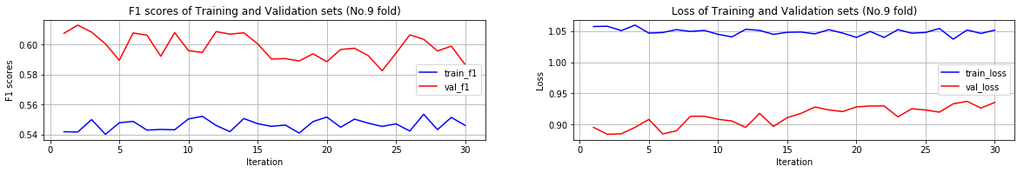

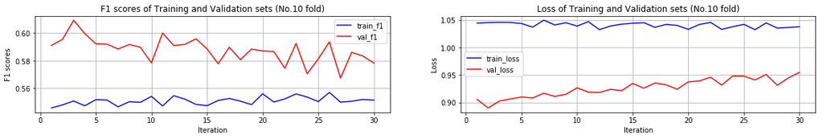

```python
# there are 10 folds, so there are 10 groups of data
for i in range(0, len(cv_training_f1_score)):
    iteration = range(1,len(cv_training_f1_score[i])+1)
    plt.figure(figsize=(20,30))

    plt.subplot(10,2,1)
    plt.plot(iteration, cv_training_f1_score[i], linestyle='-', color='blue', label='train_f1')
    plt.plot(iteration, cv_val_f1_score[i], linestyle='-', color='red', label='val_f1')
    plt.grid()
    plt.legend()
    plt.xlabel('Iteration')
    plt.ylabel('F1 scores')
    plt.title('F1 scores of Training and Validation sets (No.%.0f fold)' % (i+1))

    plt.subplot(10,2,2)
    plt.plot(iteration, cv_training_loss[i], linestyle='-', color='blue', label='train_loss')
    plt.plot(iteration, cv_val_loss[i], linestyle='-', color='red', label='val_loss')
    plt.grid()
    plt.legend()
    plt.xlabel('Iteration')
    plt.ylabel('Loss')
    plt.title('Loss of Training and Validation sets (No.%.0f fold)' % (i+1))
```

```python
iteration = np.array([i for i in range(1, len(cv_training_f1_score[0])+1)])

cv_training_f1_score_mean = np.mean(np.array(cv_training_f1_score), axis=0)
cv_training_f1_score_std = np.std(np.array(cv_training_f1_score), axis=0)

cv_training_loss_mean = np.mean(np.array(cv_training_loss), axis=0)
cv_training_loss_std = np.std(np.array(cv_training_loss), axis=0)

cv_val_f1_score_mean = np.mean(np.array(cv_val_f1_score), axis=0)
cv_val_f1_score_std = np.std(np.array(cv_val_f1_score), axis=0)

cv_val_loss_mean = np.mean(np.array(cv_val_loss), axis=0)
cv_val_loss_std = np.std(np.array(cv_val_loss), axis=0)
```

```
Text(0.5,1,'Loss vs. Iterations')
```

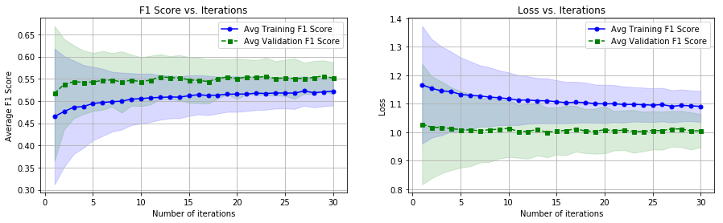

```python
plt.figure(figsize=(15,4))

plt.subplot(1,2,1)
plt.plot(iteration, cv_training_f1_score_mean, color='blue', marker='o', markersize=5, label='Avg Training F1 Score')
plt.fill_between(iteration, cv_training_f1_score_mean+cv_training_f1_score_std,
                 cv_training_f1_score_mean-cv_training_f1_score_std, alpha=0.15, color='blue')
plt.plot(iteration, cv_val_f1_score_mean, color='green', linestyle='--', marker='s', markersize=5, label='Avg Validation F1 Score')
plt.fill_between(iteration, cv_val_f1_score_mean+cv_val_f1_score_std,
                 cv_val_f1_score_mean-cv_val_f1_score_std, alpha=0.15, color='green')
plt.grid()
plt.xlabel('Number of iterations')
plt.ylabel('Average F1 Score')
plt.legend()
plt.title('F1 Score vs. Iterations')

plt.subplot(1,2,2)
plt.plot(iteration,cv_training_loss_mean, color='blue', marker='o', markersize=5, label='Avg Training F1 Score')
plt.fill_between(iteration, cv_training_loss_mean+cv_training_loss_std,
                 cv_training_loss_mean-cv_training_loss_std, alpha=0.15, color='blue')
plt.plot(iteration, cv_val_loss_mean, color='green', linestyle='--', marker='s', markersize=5, label='Avg Validation F1 Score')
plt.fill_between(iteration, cv_val_loss_mean+cv_val_loss_std,
                 cv_val_loss_mean-cv_val_loss_std, alpha=0.15, color='green')
plt.grid()
plt.xlabel('Number of iterations')
plt.ylabel('Loss')
plt.legend()
plt.title('Loss vs. Iterations')
```

We also calculate the average and standrad deviation of F1 score and average and standard deviation of loss for each iteration. Then visualize the average and standard deviation of F1 score and loss vs number of iterations. From above we can see, the f1 score of Xception Architecture model is 0.55 +- 0.05 when it converages.

### 2.2.2 ResNet performance

```python
n_folds = 10
skf = StratifiedKFold(n_splits=n_folds)

cv_training_f1_score = []
cv_training_loss = []

cv_val_f1_score = []
cv_val_loss = []

for train_indices, val_indices in skf.split(X_train, y_train):
    X_tmp_train = X_train[train_indices]
    y_tmp_train = y_train_ohe[train_indices]

    X_tmp_val = X_train[val_indices]
    y_tmp_val = y_train_ohe[val_indices]

    history = resnet.fit_generator(datagen.flow(X_tmp_train, y_tmp_train, batch_size=128),
                   steps_per_epoch=int(len(X_tmp_train)/128), # how many generators to go through per epoch
                   epochs=30, verbose=0,
                   validation_data=(X_tmp_val,y_tmp_val)
                  )

    cv_training_f1_score.append(history.history.get('f1'))
    cv_val_f1_score.append(history.history.get('val_f1'))

    cv_training_loss.append(history.history.get('loss'))
    cv_val_loss.append(history.history.get('val_loss'))
```

### (ResNet) Visualize the training and validation f1_score and loss of each iteration of every fold

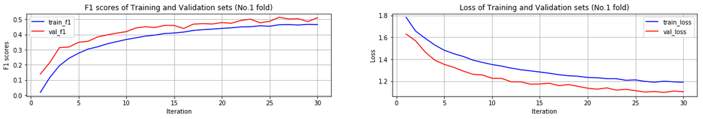

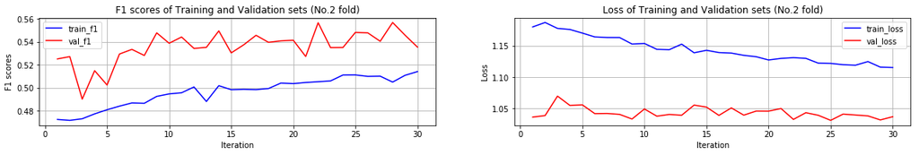

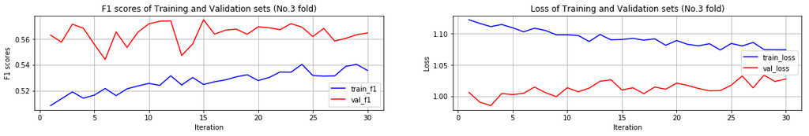

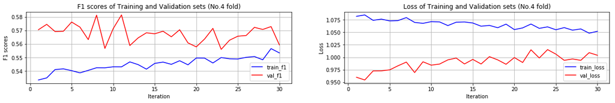

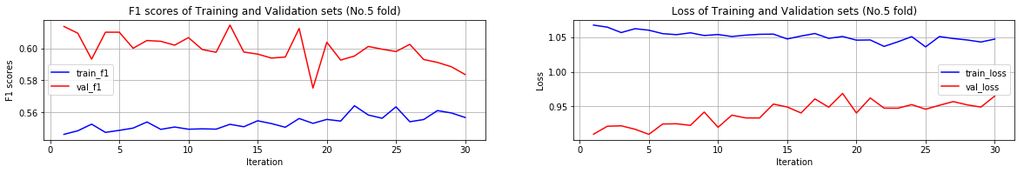

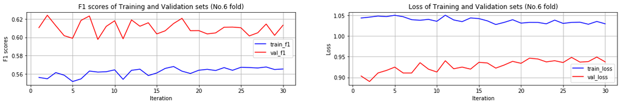

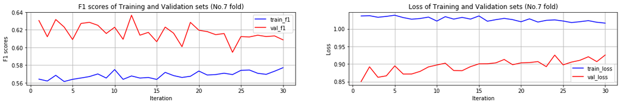

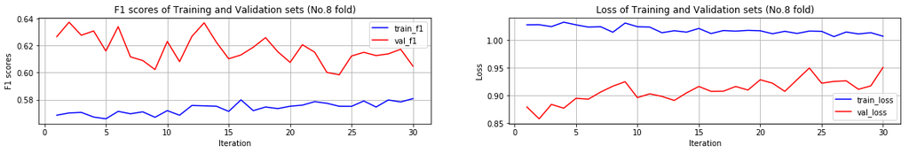

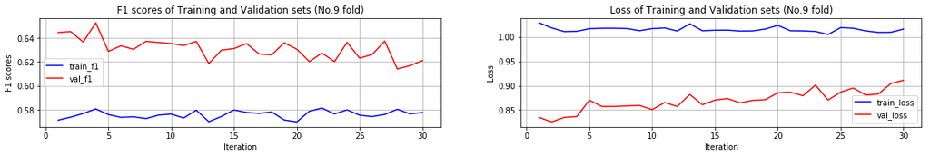

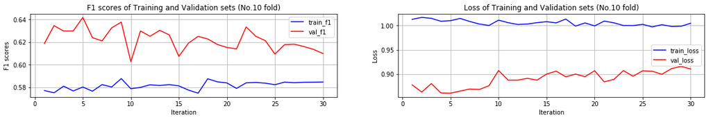

```python
# there are 10 folds, so there are 10 groups of data
for i in range(0, len(cv_training_f1_score)):
    iteration = range(1,len(cv_training_f1_score[i])+1)
    plt.figure(figsize=(20,30))
    plt.subplot(10,2,1)
    plt.plot(iteration, cv_training_f1_score[i], linestyle='-', color='blue', label='train_f1')
    plt.plot(iteration, cv_val_f1_score[i], linestyle='-', color='red', label='val_f1')
    plt.grid()
    plt.legend()
    plt.xlabel('Iteration')
    plt.ylabel('F1 scores')
    plt.title('F1 scores of Training and Validation sets (No.%.0f fold)' % (i+1))

    plt.subplot(10,2,2)
    plt.plot(iteration, cv_training_loss[i], linestyle='-', color='blue', label='train_loss')
    plt.plot(iteration, cv_val_loss[i], linestyle='-', color='red', label='val_loss')
    plt.grid()
    plt.legend()
    plt.xlabel('Iteration')
    plt.ylabel('Loss')
    plt.title('Loss of Training and Validation sets (No.%.0f fold)' % (i+1))
```

```python
iteration = np.array([i for i in range(1, len(cv_training_f1_score[0])+1)])

cv_training_f1_score_mean = np.mean(np.array(cv_training_f1_score), axis=0)
cv_training_f1_score_std = np.std(np.array(cv_training_f1_score), axis=0)

cv_training_loss_mean = np.mean(np.array(cv_training_loss), axis=0)
cv_training_loss_std = np.std(np.array(cv_training_loss), axis=0)

cv_val_f1_score_mean = np.mean(np.array(cv_val_f1_score), axis=0)
cv_val_f1_score_std = np.std(np.array(cv_val_f1_score), axis=0)

cv_val_loss_mean = np.mean(np.array(cv_val_loss), axis=0)
cv_val_loss_std = np.std(np.array(cv_val_loss), axis=0)
```

```
Text(0.5,1,'Loss vs. Iterations')
```

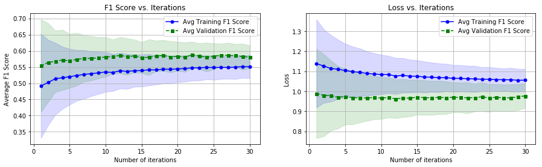

```python
plt.figure(figsize=(15,4))

plt.subplot(1,2,1)
plt.plot(iteration, cv_training_f1_score_mean, color='blue', marker='o', markersize=5, label='Avg Training F1 Score')
plt.fill_between(iteration, cv_training_f1_score_mean+cv_training_f1_score_std,
                 cv_training_f1_score_mean-cv_training_f1_score_std, alpha=0.15, color='blue')
plt.plot(iteration, cv_val_f1_score_mean, color='green', linestyle='--', marker='s', markersize=5, label='Avg Validation F1 Score')
plt.fill_between(iteration, cv_val_f1_score_mean+cv_val_f1_score_std,
                 cv_val_f1_score_mean-cv_val_f1_score_std, alpha=0.15, color='green')
plt.grid()
plt.xlabel('Number of iterations')
plt.ylabel('Average F1 Score')
plt.legend()
plt.title('F1 Score vs. Iterations')

plt.subplot(1,2,2)
plt.plot(iteration,cv_training_loss_mean, color='blue', marker='o', markersize=5, label='Avg Training F1 Score')
plt.fill_between(iteration, cv_training_loss_mean+cv_training_loss_std,
                 cv_training_loss_mean-cv_training_loss_std, alpha=0.15, color='blue')
plt.plot(iteration, cv_val_loss_mean, color='green', linestyle='--', marker='s', markersize=5, label='Avg Validation F1 Score')
plt.fill_between(iteration, cv_val_loss_mean+cv_val_loss_std,
                 cv_val_loss_mean-cv_val_loss_std, alpha=0.15, color='green')
plt.grid()
plt.xlabel('Number of iterations')
plt.ylabel('Loss')
plt.legend()
plt.title('Loss vs. Iterations')
```

We also calculate the average and standrad deviation of F1 score and average and standard deviation of loss for each iteration. Then visualize the average and standard deviation of F1 score and loss vs number of iterations. From above we can see, the f1 score of Resnet Architecture model is 0.59 +- 0.05 when it converages. Compared to Xception Architecture Model, the performance of resnet model are slightly better than Xception Model.

### 2.2.3 AlexNet Performance

```python
n_folds = 10
skf = StratifiedKFold(n_splits=n_folds)

cv_training_f1_score = []
cv_training_loss = []

cv_val_f1_score = []
cv_val_loss = []

for train_indices, val_indices in skf.split(X_train, y_train):
    X_tmp_train = X_train[train_indices]
    y_tmp_train = y_train_ohe[train_indices]

    X_tmp_val = X_train[val_indices]
    y_tmp_val = y_train_ohe[val_indices]

    history = alex_net.fit_generator(datagen.flow(X_tmp_train, y_tmp_train, batch_size=128),
                   steps_per_epoch=int(len(X_train)/128), # how many generators to go through per epoch
                   epochs=30, verbose=0,
                   validation_data=(X_tmp_val,y_tmp_val)
                  )

    cv_training_f1_score.append(history.history.get('f1'))
    cv_val_f1_score.append(history.history.get('val_f1'))

    cv_training_loss.append(history.history.get('loss'))
    cv_val_loss.append(history.history.get('val_loss'))
```